# An observational analysis of the effect of improved sanitation on linear growth in the WASH Benefits Bangladesh and Kenya trials

13 Nov 2017 (updated 28 Mar 2018)

# Overview

This script conducts an observational analysis of the relationship between improved sanitation at enrollment and LAZ at the final endpoint in the WASH Benefits trials. This is a prospective cohort study nested within the control arm of each trial, whereby our exposure is household sanitation conditions at enrollment and our outcome is length-for-age z score (LAZ) at the final endpoint, when children were about 2 years old (median age in Kenya = 22 months, median age in Bangladesh = 25 months).

In the Bangladesh trial, we defined an improved latrine as a latrine with a functional water seal. In the Kenya trial, we followed the standard WHO JMP definition for access to an improved latrine. These definitions reflect locally appropriate definitions of improved sanitation, as used in reporting the original trials.

We restricted the analyses to the control arms of each trial to avoid any complexity due to effects of intervention (in the case of nutritional arms) or changes in sanitation conditions as a result of the trial (in the case of sanitation arms).

The section Summary of Results includes the results across both countries, so if you want to skip the details and cut to the chase then click on that section in the TOC (at left) to go to the end.

To download the R markdown source code for this notebook, toggle the dropdown menu at the top right of this page to “Download Rmd”.

## Preamble

```r
# Preamble - load packages and save colors for plotting
# WASH Benefits trial analysis package
# dev. version at devtools::install_github("ben-arnold/washb")
library(washb)
```

```r
# Machine learning and TMLE packages
library(SuperLearner)
```

```r
library(tmle)
```

```r
library(sandwich)
library(lmtest)
```

```r
library(zoo)
library(gam)
```

```r
library(splines)
library(glmnet)
```

```r
library(arm)
```

```r
library(foreach)
# dm and data visualization
library(tidyverse)
```

```r
# bright color blind palette:  https://personal.sron.nl/~pault/
cblack <- "#000004FF"
cblue <- "#3366AA"
cteal <- "#11AA99"
cgreen <- "#66AA55"
cchartr <- "#CCCC55"
cmagent <- "#992288"
cred <- "#EE3333"
corange <- "#EEA722"
cyellow <- "#FFEE33"
cgrey <- "#777777"
```

# Bangladesh analysis

## Load and process the Bangladesh data

Note: these datasets are publicly available through the Open Science Framework: https://osf.io/pqzj5

```r
# load and merge the final analysis files
# treatment assignments, enrollment charactersitics, and anthropometry measurements
d_tr    <- read.csv("~/washb-obs-san/data/washb-bangladesh-tr-public.csv")
d_enrol <- read.csv('~/washb-obs-san/data/washb-bangladesh-enrol-public.csv')
d_anth  <- read.csv('~/washb-obs-san/data/washb-bangladesh-anthro-public.csv')
#  merge to final analysis files, loaded above
lazd <- left_join(d_enrol,d_tr,by=c("clusterid","block"))
lazd <- left_join(lazd,d_anth,by=c("dataid","clusterid","block"))
# filter to children with measurements at year 2 with valid LAZ measuresments
# filter to the control arm
d2 <- lazd %>%
  filter(svy==2 & laz_x==0 & tr %in% c("Control"))
# simplify the dataset by selecting covariates and exposures
# these are the pre-specified covariates from the trial
Ws <- c("month","aged","sex","birthord","momage","momedu","momheight","Nlt18","Ncomp","watmin","hfiacat","elec","floor","walls","roof","asset_wardrobe","asset_table","asset_chair","asset_khat","asset_chouki","asset_tv","asset_refrig","asset_bike","asset_moto","asset_sewmach","asset_mobile")
d <- d2 %>%
  select(block,laz,latown,latseal,Ws) %>%
  mutate(latrine=factor(ifelse(latown==0 | is.na(latown),"No latrine","Latrine")),
         implatrine=factor(ifelse(latown==1 & latseal==1,"Improved latrine","No improved latrine")))
d$implatrine[is.na(d$implatrine)] <- "No improved latrine"
d$latcat <- factor(NA,levels=c("No latrine","Latrine no water seal","Latrine with water seal"))
d$latcat[d$latrine=="No latrine"] <- "No latrine"
d$latcat[d$latrine=="Latrine" & d$implatrine=="No improved latrine"] <- "Latrine no water seal"
d$latcat[d$latrine=="Latrine" & d$implatrine=="Improved latrine"] <- "Latrine with water seal"
```

## Distribution of LAZ at the two year measurement by access to improved latrines

This is a summary of children in the control arm at the final endpoint, stratified by latrine access at enrollment:

```r
# table of latrine type, with mean LAZ and SDs
b_lattable <- as.data.frame(table(d$latcat))
# mean and SD
b_musd <- d %>%
  group_by(latcat) %>%
  select(latcat, laz) %>%
  summarize(n=n(),
            pct=sprintf("%1.0f",100*(n/sum(b_lattable$Freq))),
            mean=mean(laz),
            sd=sd(laz))
colnames(b_musd) <- c("Sanitation at enrollment","N children","(%)","Mean LAZ","SD LAZ")
knitr::kable(b_musd,digits=c(0,0,0,3,3),format="markdown")
```

| Sanitation at enrollment | N children | (%) | Mean LAZ | SD LAZ |
| --- | --- | --- | --- | --- |
| No latrine | 513 | 47 | -1.894 | 0.980 |
| Latrine no water seal | 391 | 35 | -1.856 | 0.997 |
| Latrine with water seal | 199 | 18 | -1.374 | 1.008 |

This is a summary of the LAZ distributions by the different groups:

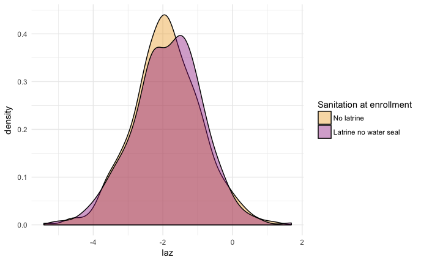

```r
# plot distributions of LAZ stratified by latrine ownership at enrollment
p1 <- ggplot(data=filter(d,latcat!="Latrine with water seal"), aes(x=laz,group=latcat,fill=latcat)) +
  geom_density(alpha=0.4) +
  scale_fill_manual(values=c(corange,cmagent),
                    guide=guide_legend(title="Sanitation at enrollment")) +
  theme_minimal()
p1
```

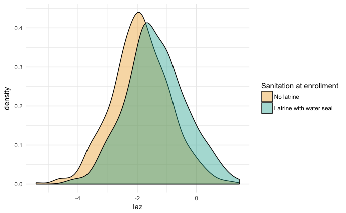

```r
p2 <- ggplot(data=filter(d,latcat!="Latrine no water seal"), aes(x=laz,group=latcat,fill=latcat)) +
  geom_density(alpha=0.4) +
  scale_fill_manual(values=c(corange,cteal),
                    guide=guide_legend(title="Sanitation at enrollment")) +
  theme_minimal()
p2
```

## Association between access to an improved latrine and LAZ

Estimate the difference in LAZ between children born into households that have a latrine with a functional water seal versus those born into households without a latrine. The estimator is a genearlized linear model (GLM) with robust, sandwich standard errors clustered at the block level, which was the independent unit in the trial. Adjusted estimates screen pre-specified covariates using a likelihood ratio test.

```r
# unadjusted
b_glmest_unadj <- washb_glm(Y=d$laz,tr=d$latcat,id=d$block,
                            contrast=c("No latrine","Latrine with water seal"))
```

```
-----------------------------------------
 GLM Fit: Latrine with water seal vs. No latrine
-----------------------------------------
                              Coef.      2.5%     97.5% Std. Error  z value
trLatrine with water seal 0.5200683 0.3440009 0.6961356  0.0898303 5.789453
                                   Pr(>|z|)
trLatrine with water seal 0.000000007061599
```

```r
# adjusted
b_glmest_adj <- washb_glm(Y=d$laz,tr=d$latcat,W=d[Ws],id=d$block,
                          contrast=c("No latrine","Latrine with water seal"))
```

```
-----------------------------------------
Dropping 6 observations due to missing values in 1 or more variables
 Final sample size: 706
-----------------------------------------

-----------------------------------------
Pre-screening the adjustment covariates:
-----------------------------------------

Likelihood Ratio Test P-values:
               P-value
month          0.83067
aged           0.76364
sex            0.79242
birthord       0.00000
momage         0.30098
momedu         0.00000
momheight      0.00000
Nlt18          0.06824
Ncomp          0.10751
watmin         0.64017
hfiacat        0.00013
elec           0.00000
floor          0.00000
walls          0.53965
roof           0.45929
asset_wardrobe 0.00000
asset_table    0.00103
asset_chair    0.00000
asset_khat     0.00000
asset_chouki   0.00243
asset_tv       0.00000
asset_refrig   0.00000
asset_bike     0.09432
asset_moto     0.00000
asset_sewmach  0.02966
asset_mobile   0.01257


Covariates selected (P<0.2):
```

[output cut: 37 more lines]

```
hfiacatModerately Food Insecure  0.01066081 -0.17962502  0.20094664
hfiacatSeverely Food Insecure    0.07897930 -0.20969162  0.36765022
elec                             0.09195769 -0.07198243  0.25589782
floor                            0.19990013 -0.01302043  0.41282068
asset_wardrobe                   0.22448134  0.01420522  0.43475745
asset_table                     -0.00197888 -0.18968049  0.18572272
asset_chair                      0.10091079 -0.07456292  0.27638450
asset_khat                       0.20452258  0.03028987  0.37875528
asset_chouki                    -0.05429240 -0.24306253  0.13447772
asset_tv                         0.03289008 -0.15342942  0.21920959
asset_refrig                     0.16140511 -0.10846332  0.43127355
asset_bike                       0.02139492 -0.13438373  0.17717357
asset_moto                       0.09503119 -0.13120333  0.32126571
asset_sewmach                   -0.01352269 -0.24143107  0.21438569
asset_mobile                    -0.03592414 -0.23638673  0.16453846
```

## Double-robust, targeted maximum likelihood estimation (TMLE)

This estimator follows the pre-specified, adjusted analysis methods from the main trial. In our view, this is the most aggressive statistical adjustment possible given the design of a fixed exposure and prospectivly measured outcome. Targeted maximum likelihood estimation is a double-robust approach that models both the outcome and the treatment mechanism (here: access to improved sanitation at enrollment). It allows for flexible estimation of each model using ensemble machine learning. We used the same ensemble and pre-specified covariates as was used in the trial’s primary analysis (simple mean, GLM, Bayes GLM, GAM with cubic splines, LASSO). Standard errors are based on the influence curve and treat blocks as the independent unit (as in the main trial).

```r
set.seed(12345)
b_tmleest_adj <- washb_tmle(Y=d$laz,tr=d$latcat,W=d[Ws],
                          id=d$block,
                          contrast=c("No latrine","Latrine with water seal"),
                          Q.SL.library=c("SL.mean","SL.glm","SL.bayesglm","SL.gam","SL.glmnet"))
```

```
-----------------------------------------
Total of 6 observations dropped due to missing
values in one or more variables
  Final sample size: 706
-----------------------------------------

-----------------------------------------
Pre-screening the adjustment covariates
using a univariate liklihood ratio test:
-----------------------------------------

Likelihood Ratio Test P-values:
               P-value
month          0.83067
aged           0.76364
sex            0.79242
birthord       0.00000
momage         0.30098
momedu         0.00000
momheight      0.00000
Nlt18          0.06824
Ncomp          0.10751
watmin         0.64017
hfiacat        0.00013
elec           0.00000
floor          0.00000
walls          0.53965
roof           0.45929
asset_wardrobe 0.00000
asset_table    0.00103
asset_chair    0.00000
asset_khat     0.00000
asset_chouki   0.00243
asset_tv       0.00000
asset_refrig   0.00000
asset_bike     0.09432
asset_moto     0.00000
asset_sewmach  0.02966
asset_mobile   0.01257

```

[output cut: 52 more lines]

```
 Estimation of g.Z (intermediate variable assignment mechanism)
     Procedure: No intermediate variable

 Estimation of g.Delta (missingness mechanism)
     Procedure: No missingness

 Bounds on g: ( 0.025 0.975 )

 Additive Effect
   Parameter Estimate:  0.21743
   Estimated Variance:  0.0089237
              p-value:  0.021349
    95% Conf Interval: (0.032283, 0.40259)

-----------------------------------------
```

# Kenya analysis

## Load and process the Kenya data

Note: these datasets are publicly available through the Open Science Framework: https://osf.io/uept9/

```r
# load and merge the final analysis files
# In Kenya, the anthropometry data from visit 2 already has
# covariates merged to it (including treatment information)
# However, one of the pre-specified covariates was not
# improved latrine ownership at enrollment, so add that from
# the data used to create Table 1 from the manuscript
dk_enrol <- read.csv("~/washb-obs-san/data/washb-kenya-uptake-baseline-public.csv")
dk_tr    <- read.csv("~/washb-obs-san/data/washb-kenya-tr-public.csv")
dk_anth  <- read.csv("~/washb-obs-san/data/washb-kenya-endline-anthro-public.csv")
# restrict enrollment measures to improved latrine and merge
# to the anthropometry measures at the year 2 visit
dk_enrol <- dk_enrol %>%
  select(clusterid,hhid,implat=imp_lat)
dk <- left_join(dk_tr,dk_enrol,by=c("clusterid"))
dk <- left_join(dk,dk_anth,by=c("block","clusterid","hhid"))
# filter to just index children in the control arms
dk <- dk %>%
  filter(targetchild==1 & tr %in% c("Control","Passive Control"))
# there were 150/2272 children (6%) for whom improved latrine status
# was missing.  Exclude them (missing at random assumption)
# there were 21 with unrealistic LAZ measurements. Exclude them
dk <- dk %>%
  filter(!is.na(implat) & !is.na(haz))
# select pre-specified covariates from the primary outcomes
# excluding staffid since it is sparse without extensive recoding
# ensure factors are coded correctly
# this follows the primary outcome adjusted analysis (line ~74):
# https://github.com/jadebc-berkeley/WBK-primary-outcomes/blob/master/primary/analysis/0-base-programs.R
kWs <- c("month","HHS","agey","sex","mother_age","motherht","mother_edu",
    "u18","Ncomp","water_time","floor","roof","cow",
    "goat","chicken","dog","elec","radio","tv","mobilephone",
    "clock","bicycle","motorcycle","stove")
kd <- dk %>%
  select(block,clusterid,tr,laz=haz,implat,kWs)
# reorder factor values to so that the reference is
# not having something instead of the first thing alphabetically
kd$month <-  as.factor(kd$month)
kd$clock <- relevel(kd$clock,ref="No clock")
kd$elec <- relevel(kd$elec,ref="No electricity")
kd$mother_edu=relevel(kd$mother_edu,ref="Incomplete primary")
kd$roof <- relevel(kd$roof,ref="Thatch/leaf")
kd$floor <- relevel(kd$floor,ref="Earth/dung")
kd$bicycle <- relevel(kd$bicycle,ref="No bicycle")
kd$radio <- relevel(kd$radio,ref="No radio")
kd$tv <- relevel(kd$tv,ref="No TV")
kd$mobilephone <- relevel(kd$mobilephone,ref="No mobile phone")
kd$stove <- relevel(kd$stove,ref="No stove")
# formally code improved latrine
kd$latcat <- factor(ifelse(kd$implat==1,"Improved latrine","No improved latrine"),levels=c("No improved latrine","Improved latrine"))
```

## Distribution of LAZ at the two year measurement by access to improved latrines

This is a summary of children in the active and passive control arms at the final endpoint, stratified by latrine access at enrollment:

```r
# table of latrine type, with mean LAZ and SDs
k_lattable <- as.data.frame(table(kd$latcat))
# mean and SD
k_musd <- kd %>%
  group_by(latcat) %>%
  select(latcat, laz) %>%
  summarize(n=n(),
            pct=sprintf("%1.0f",100*(n/sum(k_lattable$Freq))),
            mean=mean(laz),
            sd=sd(laz))
colnames(k_musd) <- c("Sanitation at enrollment","N children","(%)","Mean LAZ","SD LAZ")
knitr::kable(k_musd,digits=c(0,0,0,3,3),format="markdown")
```

| Sanitation at enrollment | N children | (%) | Mean LAZ | SD LAZ |
| --- | --- | --- | --- | --- |
| No improved latrine | 1737 | 83 | -1.578 | 1.081 |
| Improved latrine | 364 | 17 | -1.330 | 1.084 |

This is a summary of the LAZ distributions by the different groups:

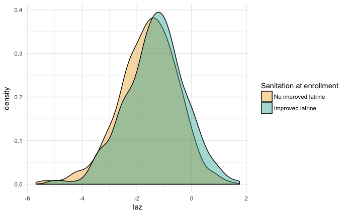

```r
# plot distributions of LAZ stratified by baseline latrine ownership
ggplot(data=kd,aes(x=laz,group=latcat,fill=latcat)) +
  geom_density(alpha=0.4) +
  scale_fill_manual(values=c(corange,cteal),
                    guide=guide_legend(title="Sanitation at enrollment")) +
  theme_minimal()
```

## Association between access to an improved latrine and LAZ

```r
# unadjusted
k_glmest_unadj <- washb_glm(Y=kd$laz,tr=kd$latcat,id=kd$block,
                            contrast=c("No improved latrine","Improved latrine"))
```

```
-----------------------------------------
 GLM Fit: Improved latrine vs. No improved latrine
-----------------------------------------
                       Coef.      2.5%     97.5% Std. Error  z value      Pr(>|z|)
trImproved latrine 0.2479052 0.1232202 0.3725903 0.06361481 3.896974 0.00009740218
```

```r
# adjusted
k_glmest_adj <- washb_glm(Y=kd$laz,tr=kd$latcat,W=kd[kWs],id=kd$block,
                          contrast=c("No improved latrine","Improved latrine"))
```

```
-----------------------------------------
Dropping 164 observations due to missing values in 1 or more variables
 Final sample size: 1937
-----------------------------------------

-----------------------------------------
Pre-screening the adjustment covariates:
-----------------------------------------

Likelihood Ratio Test P-values:
            P-value
month       0.41581
HHS         0.01380
agey        0.00602
sex         0.00001
mother_age  0.00017
motherht    0.00000
mother_edu  0.00000
u18         0.00239
Ncomp       0.04760
water_time  0.59419
floor       0.00724
roof        0.14014
cow         0.00625
goat        0.13611
chicken     0.00988
dog         0.18957
elec        0.00649
radio       0.16068
tv          0.00103
mobilephone 0.00135
clock       0.02504
bicycle     0.31627
motorcycle  0.58492
stove       0.00000


Covariates selected (P<0.2):
                 P-value
HHS         1.379557e-02
```

[output cut: 37 more lines]

```
u18                          -0.06228162 -0.09267246 -0.03189078
Ncomp                        -0.00451917 -0.01299730  0.00395895
floorCement/concrete         -0.00694482 -0.21659605  0.20270640
floorMissing/DK              -1.00035315 -1.27069155 -0.73001475
roofIron/other               -0.00036013 -0.10892189  0.10820162
cow                           0.02128260 -0.01563309  0.05819829
goat                          0.01228318 -0.02937551  0.05394187
chicken                       0.00183331 -0.00334463  0.00701126
dog                           0.01876128 -0.03584364  0.07336620
elecHas electricity           0.09812476 -0.10920199  0.30545151
radioHas radio               -0.00708682 -0.11170660  0.09753296
tvOwns TV                     0.10017201 -0.02940975  0.22975376
mobilephoneAny mobile phones  0.10436950 -0.04396080  0.25269979
clockHas clock               -0.00749205 -0.14445876  0.12947466
stoveHas stove                0.12874814  0.01422996  0.24326632
```

## Double-robust, targeted maximum likelihood estimation (TMLE)

This estimator follows the pre-specified, adjusted analysis methods from the main trial. In our view, this is the most aggressive statistical adjustment possible given the design of a fixed exposure and prospectivly measured outcome. Targeted maximum likelihood estimation is a double-robust approach that models both the outcome and the treatment mechanism (here: access to improved sanitation at enrollment). It allows for flexible estimation of each model using ensemble machine learning. We used the same ensemble and pre-specified covariates as was used in the trial’s primary analysis (simple mean, GLM, Bayes GLM, GAM with cubic splines, LASSO). Standard errors are based on the influence curve and treat blocks as the independent unit (as in the main trial).

```r
set.seed(12345)
k_tmleest_adj <- washb_tmle(Y=kd$laz,tr=kd$latcat,W=kd[kWs],
                          id=kd$block,
                          contrast=c("No improved latrine","Improved latrine"),
                          Q.SL.library=c("SL.mean","SL.glm","SL.bayesglm","SL.gam","SL.glmnet"))
```

```
-----------------------------------------
Total of 164 observations dropped due to missing
values in one or more variables
  Final sample size: 1937
-----------------------------------------

-----------------------------------------
Pre-screening the adjustment covariates
using a univariate liklihood ratio test:
-----------------------------------------

Likelihood Ratio Test P-values:
            P-value
month       0.41581
HHS         0.01380
agey        0.00602
sex         0.00001
mother_age  0.00017
motherht    0.00000
mother_edu  0.00000
u18         0.00239
Ncomp       0.04760
water_time  0.59419
floor       0.00724
roof        0.14014
cow         0.00625
goat        0.13611
chicken     0.00988
dog         0.18957
elec        0.00649
radio       0.16068
tv          0.00103
mobilephone 0.00135
clock       0.02504
bicycle     0.31627
motorcycle  0.58492
stove       0.00000


Covariates selected (P<0.2):
```

[output cut: 51 more lines]

```
 Estimation of g.Z (intermediate variable assignment mechanism)
     Procedure: No intermediate variable

 Estimation of g.Delta (missingness mechanism)
     Procedure: No missingness

 Bounds on g: ( 0.025 0.975 )

 Additive Effect
   Parameter Estimate:  0.15115
   Estimated Variance:  0.0044987
              p-value:  0.024224
    95% Conf Interval: (0.01969, 0.28261)

-----------------------------------------
```

# Summary of results

In both trials, access to improved sanitation at enrollment was associated with improved LAZ at the final endpoint. In unadjusted analyses, the effects were +`0.52`Z (Bangladesh) and +`0.25`Z (Kenya).

Effects were attenuated after adjusting for a broad set of potentially confounding covariates using ensemble machine learning and double-robust, targeted maximum likelihood estimation. In Bangladesh, the effect was reduced to +`0.22`Z (p=`0.021`). In Kenya, the effect was reduced to +`0.15`Z (p=`0.024`).

Adjusted estimates using simple generalized linear models (GLM) were very similar to the more aggressivly adjusted TMLE estimates. The consistency in the point estimates between the two adjusted analyses suggests that the residual bias from unobserved confounding cannot be salvaged from more aggressive estimation approaches, even double-robust estimators that include flexible machine learning.

Bangladesh trial results (see Fig 3B): https://www.ncbi.nlm.nih.gov/pubmed/29396217

Kenya trial results (see Fig 3C): https://www.ncbi.nlm.nih.gov/pubmed/29396219

The contrast between the trials’ findings and these observational analysis results underscore the importance of randomized controlled trials for exposures and outcomes that are inextricably linked with broader improvements in overall wellbeing.

## Bangladesh

|  | Diff LAZ | Lower 95% | Upper 95% | P-value |
| --- | --- | --- | --- | --- |
| Unadjusted | 0.520 | 0.344 | 0.696 | 0.000 |
| Adjusted, GLM | 0.200 | -0.009 | 0.410 | 0.061 |
| Adjusted, double-robust TMLE | 0.217 | 0.032 | 0.403 | 0.021 |

## Kenya

|  | Diff LAZ | Lower 95% | Upper 95% | P-value |
| --- | --- | --- | --- | --- |
| Unadjusted | 0.248 | 0.123 | 0.373 | 0.000 |
| Adjusted, GLM | 0.162 | 0.046 | 0.278 | 0.006 |
| Adjusted, double-robust TMLE | 0.151 | 0.020 | 0.283 | 0.024 |